# Sampling Distribution Demo

Author

Bárbara D. Bitarello

Published

October 21, 2026

Modified

October 26, 2026

## The human_genes dataset

Overall goal of this exercise is to compare sample medians at different sample sizes to the population median.

First, let’s read in this dataset:

```r
library(tidyverse)
human_genes <- read_csv("https://whitlockschluter3e.zoology.ubc.ca/Data/chapter04/chap04e1HumanGeneLengthsLongestTranscript.csv")
```

Play around with it using your strong exploratory data analysis skills. Get a good feel for the data set. Using functions (not the Rstudio tabs) explore how many rows and columns there are, their types, etc.

```r
str(human_genes)
```

```
spc_tbl_ [22,385 × 4] (S3: spec_tbl_df/tbl_df/tbl/data.frame)
 $ gene       : chr [1:22385] "ENSG00000000003.14" "ENSG00000000005.5" "ENSG00000000419.12" "ENSG00000000457.13" ...
 $ size       : num [1:22385] 3796 1339 1161 6364 4355 ...
 $ name       : chr [1:22385] "TSPAN6" "TNMD" "DPM1" "SCYL3" ...
 $ description: chr [1:22385] "tetraspanin" "tenomodulin" "dolichyl-phosphate" "SCY1" ...
 - attr(*, "spec")=
  .. cols(
  ..   gene = col_character(),
  ..   size = col_double(),
  ..   name = col_character(),
  ..   description = col_character()
  .. )
 - attr(*, "problems")=<pointer: 0x796fa59d0>
```

```r
glimpse(human_genes)
```

```
Rows: 22,385
Columns: 4
$ gene        <chr> "ENSG00000000003.14", "ENSG00000000005.5", "ENSG0000000041…
$ size        <dbl> 3796, 1339, 1161, 6364, 4355, 2729, 4127, 2356, 3813, 3811…
$ name        <chr> "TSPAN6", "TNMD", "DPM1", "SCYL3", "C1orf112", "FGR", "CFH…
$ description <chr> "tetraspanin", "tenomodulin", "dolichyl-phosphate", "SCY1"…
```

```r
dim(human_genes)
```

```
[1] 22385     4
```

```r
table(is.na(human_genes)) # there are some NAs
```

```
FALSE  TRUE
89108   432
```

There are some NAs. Since what we care about is the variable `size`, let’s check for NAs there specificially:

```r
human_genes |>
  filter(is.na(size)) |>
  nrow() # none! all good
```

```
[1] 0
```

Plot a distribution of the gene lengths (this is stored in the column called `size`) using ggplot.

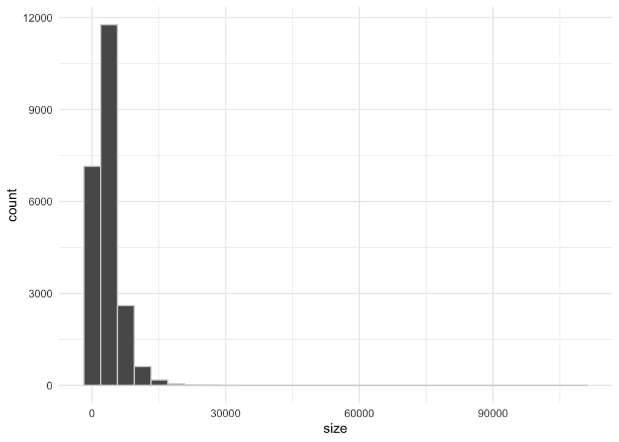

```r
ggplot(human_genes, aes(x = size)) +
  geom_histogram(color = "lightgray") + # color here refers to the line around each bar
  theme_minimal() # makes ggplots look cleaner
```

Can we make this plot better by changing the number of bins in the histogram?

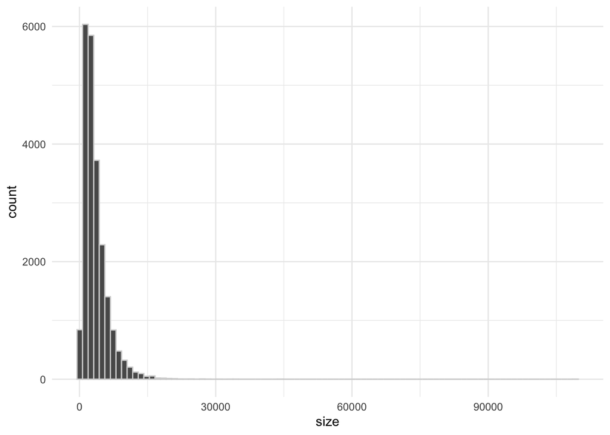

```r
ggplot(human_genes, aes(x = size)) +
  geom_histogram(color = "lightgray", bins = 90) + # color here refers to the line around each bar
  theme_minimal() # makes ggplots look cleaner
```

As we can see, this distribution is heavily skewed. A relatively low number of genes are super huge. Let’s look at their mean and median lengths:

```r
human_genes |>
  summarise(mean_size = mean(size), median_size = median(size))
```

```
# A tibble: 1 × 2
  mean_size median_size
      <dbl>       <dbl>
1     3511.        2744
```

Because the human genome has relatively few genes that are super huge, a large sample size might be more likely to include one of those giant genes and mess up your mean. So we will use the median instead.

### Sampling the human_genes dataset

Now let’s take some samples. Take 3 samples of gene size with replacement on[^1]. Use `n = 10`, `n=100`, `n=1000`. Calculate the median of these samples, and save each median as median10, median100, and median1000.

```r
# 10 genes
median10 <- human_genes |>
  slice_sample(n = 10, replace = T) |>
  summarise(median = median(size))
# 100 genes
median100 <- human_genes |>
  slice_sample(n = 100, replace = T) |>
  summarise(median = median(size))
# 1000 genes
median1000 <- human_genes |>
  slice_sample(n = 1000, replace = T) |>
  summarise(median = median(size))
```

Which of these medians is closest to the population median?

## Generating a distribution of medians

Now let’s combine this with the skills you learned in loops. You are going to take 100 samples of each of those sample sizes to compare.

First you want to create 3 vectors to store each of your results. You can use the function `numeric()` to generate vectors of the desired length, which will here be filled with 0s and after you perform your loop, the 0s will be replaced with samples. They act like the placeholder vectors we used earlier when exploring loops. This saves R some overhead compared to creating an empty vector that you keep expanding. I did this part for you:

```r
# empty objects where you will store your medians
medians_10 <- numeric(100)
medians_100 <- numeric(100)
medians_1000 <- numeric(100)
```

Now, using objects above to store your results, run 100 iterations of sampling (10,100, or 1000 genes) using a for loop (or using apply or lapply). * For each iteration, sample 10,100, or 1000 genes as we did above (code chunk ex9a) and calculate the medians of their sizes. * Store each median in the objects created in the previous chunk. * We can include all three of your new vectors in the same loop since all 3 of them have the same length.

```r
# option 1: for loops
for (i in 1:100) {
  medians_10[i] <- median(sample(human_genes$size,
    size = 10, replace = T
  ))
  medians_100[i] <- median(sample(human_genes$size,
    size = 100, replace = T
  ))
  medians_1000[i] <- median(sample(human_genes$size,
    size = 1000, replace = T
  ))
}
```

That was option 1. Here’s the same thing but using `lapply`:

```r
# option 2: lapply
medians_10 <- lapply(1:100, function(i) {
  median(sample(human_genes$size,
    size = 10, replace = T
  ))
})
medians_100 <- lapply(1:100, function(i) {
  median(sample(human_genes$size,
    size = 100, replace = T
  ))
})
medians_1000 <- lapply(1:100, function(i) {
  median(sample(human_genes$size,
    size = 1000, replace = T
  ))
})
```

That was option 2. Now here’s a third (fancy) option using a combination of loops and slice_sample() (recap from lab 5).

```r
# option 3 (fancy)
for (i in 1:100) {
  medians_10[i] <- human_genes |>
    slice_sample(n = 10, replace = T) |>
    summarise(median = median(size))
  medians_100[i] <- human_genes |>
    slice_sample(n = 100, replace = T) |>
    summarise(median = median(size))
  medians_1000[i] <- human_genes |>
    slice_sample(n = 1000, replace = T) |>
    summarise(median = median(size))
}

# check
head(medians_100) # this is a list
```

```
[[1]]
[1] 2493

[[2]]
[1] 2559

[[3]]
[1] 2798.5

[[4]]
[1] 2278.5

[[5]]
[1] 2429

[[6]]
[1] 2583.5
```

Note: if you used `summarise` in your loop, you will end up with a list instead of a vector. You can fix this easily by running `unlist` on your medians_ objects.

```r
# Only run this if your medians_10, etc objects have become lists. If so, set the chunk to eval=T

medians_10 <- unlist(medians_10)
medians_100 <- unlist(medians_100)
medians_1000 <- unlist(medians_1000)
```

Let’s make a tibble with 3 columns:

- sample_size: 10, 100, or 1,000
- median_gene_length: the medians you just calculated
- replicate: 1:100

It may be easier to start with 3 separate tibbles:

```r
## the function rep repeats something a number of times:
# 10
tibble10 <- tibble(
  sample_size = rep(x = 10, 100),
  median_gene_length = medians_10,
  replicate = 1:100
)
tibble10
```

```
# A tibble: 100 × 3
   sample_size median_gene_length replicate
         <dbl>              <dbl>     <int>
 1          10              1568.         1
 2          10              1586.         2
 3          10              2912          3
 4          10              2860.         4
 5          10              2756          5
 6          10              3398          6
 7          10              4428.         7
 8          10              2190.         8
 9          10              2122          9
10          10              3508         10
# ℹ 90 more rows
```

```r
# 100
tibble100 <- tibble(
  sample_size = rep(x = 100, 100),
  median_gene_length = medians_100,
  replicate = 1:100
)
tibble100
```

```
# A tibble: 100 × 3
   sample_size median_gene_length replicate
         <dbl>              <dbl>     <int>
 1         100              2493          1
 2         100              2559          2
 3         100              2798.         3
 4         100              2278.         4
 5         100              2429          5
 6         100              2584.         6
 7         100              2762.         7
 8         100              2986.         8
 9         100              3232.         9
10         100              2978         10
# ℹ 90 more rows
```

```r
# 1000
tibble1000 <- tibble(
  sample_size = rep(x = 1000, 100),
  median_gene_length = medians_1000,
  replicate = 1:100
)
tibble1000
```

```
# A tibble: 100 × 3
   sample_size median_gene_length replicate
         <dbl>              <dbl>     <int>
 1        1000              2592          1
 2        1000              2782.         2
 3        1000              2746.         3
 4        1000              2749          4
 5        1000              2809          5
 6        1000              2722          6
 7        1000              2868          7
 8        1000              2722          8
 9        1000              2868.         9
10        1000              2638.        10
# ℹ 90 more rows
```

Next we combine them into a single object. There are two ways of doing this. One is `rbind` (base R) and the other one is `bind_rows` (tidyverse). Let’s try both below and save the final object as `all_medians`.

```r
# your code here
# option 1
all_medians <- rbind(tibble10, tibble100, tibble1000)
# option 2
all_medians <- bind_rows(tibble10, tibble100, tibble1000)
```

Using `group_by` and `summarise`, calculate the “mean of medians” for each sample size. Which of your sample sizes gets you closest to the population median?

```r
# median for all genes
# the function 'pull()' pulls a given column and turns its values into a vector.
median_all_genes <- human_genes |>
  summarise(median = median(size)) |>
  pull(median)
median_all_genes
```

```
[1] 2744
```

Compare your medians of medians to the median_all_genes:

```r
# compare your mean of medians to the median_all_genes

all_medians |>
  group_by(sample_size) |>
  summarise(mean_of_medians = mean(median_gene_length))
```

```
# A tibble: 3 × 2
  sample_size mean_of_medians
        <dbl>           <dbl>
1          10           2781.
2         100           2791.
3        1000           2740.
```

Lastly, let’s make a multiple histograms plot for our three sample sizes. Use facet_wrap on sample_size to do this. To make the plot look better, set `nrow=3` in `facet_wrap`. Remember to not jsut accept the default number of bins. What do you notice about the spread of these 3 distributions? I will also add a vertical line showing the actual median gene length from the entire dataset:

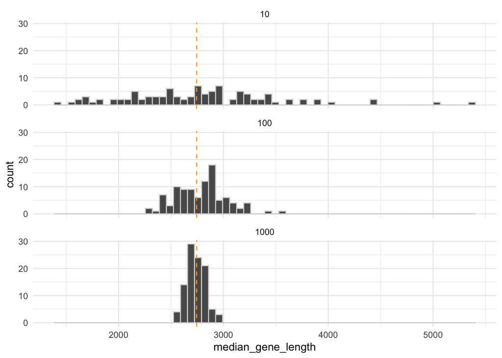

```r
medReal <- median(human_genes$size)
# your code here
ggplot(all_medians, aes(x = median_gene_length)) +
  geom_histogram(color = "lightgray", bins = 60) +
  facet_wrap(~sample_size, nrow = 3) +
  geom_vline(xintercept = medReal, lty = 2, color = "orange") +
  theme_minimal()
```

## Standard Error

Recall that the standard error of a statist is the standard deviation of its sampling distribution.

Let’s calculate the standard deviation for all the replicates for each sample size:

```r
all_medians |>
  group_by(sample_size) |>
  summarise(mean = mean(median_gene_length), sem = sd(median_gene_length))
```

```
# A tibble: 3 × 3
  sample_size  mean   sem
        <dbl> <dbl> <dbl>
1          10 2781. 720.
2         100 2791. 241.
3        1000 2740.  82.1
```

In agreement with the multiple histograms above, the larger sample size has a smaller standard error associated with the sampling distribution (more narrow) and the smaller sample size has a wider spread (higher standard error of the median). Congrats! You have just generated sampling distributions for the median for 3 sample sizes! The sampling distribution is a central concept in estimation of confidence intervals and in hypothesis testing.

## Footnotes

[^1]: why, you might ask? In most situations, it should be reasonable to assume that by sampling some individuals from a population we don’t affect the population itself. That’s not always true, however.